# Cars Price Prediction

**Group Name:180**:

Somesh Valse:(s3951107)----> [(50%)contribution]

Harshith Hullakere Siddegowda:(s3914263)----> [(50%)contribution]

The objective of this case study is to assist the sellers, buyers, in the used car market. Based on the information provided by the users, it may then provide a relatively accurate price estimate, understand what are all the attribute feature effect on the price of a car, selecting the right features which plays a significant role in predicting the price of a car. The dataset for automobile prices utilised in the study was obtained from kaggle. This dataset contains automobile pricing from year 1939 until 2020. The descriptive feature include This dataset has 17 features and 19237 observations in total. Target variable is continous numeric variable.

- Introduction
  - Phase 1 Summary:
  - Report Overview:
  - Overview of Methodology:
- Predictive Modelling:
  - Feature Selection (FS)
  - Model Fitting & Tuning:
  - Neural Network Model Fitting & Tuning:
  - Model Comparison
- Critique & Limitations
- Summary & Conclusions:
  - Project Summary:
  - Summary of Findings:
  - Conclusions:

# **Introduction**

The objective of this case study is to assist the sellers, buyers, in the used car market. Based on the information provided by the users, it may then provide a relatively accurate price estimate, understand what are all the attribute feature effect on the price of a car, selecting the right features which plays a significant role in predicting the price of a car. The dataset for automobile prices utilised in the study was obtained from kaggle. This dataset contains automobile pricing from year 1939 until 2020. The descriptive feature include This dataset has 17 features and 19237 observations in total. Target variable is continous numeric variable.

### Phase 1 Summary

In Phase 1 project we deployed several data cleaning, preprocessing, and data visualisation techniques. we chose to remove extraneous columns, namely ID variables. So we chose to partition our dataset into two categories of variables: category and numerical variables, and then conduct our analysis. We also evaluated our dataset for missing data, outliers, and imbalance, and we opted to eliminate any rows with such data quality concerns. Because the data appeared to be quite clean to begin with, cleaning was minimal. Moreover, we used a correlations matrix to better assess the strength of the association between distinct factors.

We created numerous visualisations to analyse the data using the explanatory factors. It was apparent that the majority of people like to buy sedan vehicles, followed by jeep and hatchback cars in black, silver, and white, and that the prefered fuel type is petrol, followed by diesel and hybrid.

We also noticed that several of the numerical statistics, such as the goal variables and pricing, are skewed. To overcome this issue, data scaling/transformation will be required. We've seen that tax, fuel type, colour, and category type all play important roles in determining automobile prices.

We will expand on the work done in Phase 1 to better prepare the dataset for analysis and modelling in Phase 2. We will concentrate on encoding category variables into numeric variables and scaling the numerical variables to ensure they are all on the same scale.

This will allow us to apply a broader set of statistical analysis and machine learning techniques to the information in order to find the primary factors influencing automotive costs. We will also obtain a better grasp of the correlations between factors such as tax, fuel type, colour, and category type, as well as how these affect automotive pricing.

We can construct more accurate pricing models by undertaking a more extensive investigation. by dealerships and customers to make better informed judgements while purchasing or selling automobiles. Overall, the Phase 2 project will expand on the work completed in Phase 1 to allow for more sophisticated analysis and modelling, resulting in more accurate and actionable findings.

### Report Overview

Our Report will be organize as follows

1) **Data Preparation** :- We are going to summarizes the data preparation process and our model evaluation strategy.

2) **Encoding Categorical Features** :- In this section we are converting categorical features into vector format for the futher analysis.

3) **Scaling of Features** :- we are going to convert numerical feature into a consistent range or distribution to ensure they equally contribute for the model training process.

4) **Feature Selection & Ranking** :- In this section, we select most relevant and information features from the dataset, to improve model accuracy for analysis.

5) **Data Sampling & Train-Test Splitting** :- In this part, we divide our dataset to assess the performance of the datset.

6) **Model Evaluation Startegy** :- For this section, we are going to implement systematic apporach to assess the performance of the machine learning algorithm.

7) **Discussion** :- In this section we are going to discuss about our analysis regarding model development and performace of each model.

8) **Limitations and Proposed Solutions** :- we'll discuss our limitation and proposed solution for our approach.

9) **Summary** :- In this part, we are going to see overall summary of our project.

## Overview Of Methodology

We consider the following regression model to predict our target feature:

```
    1) KNN Regressor

    2) Decision Tree

    3) Random Forest Regressor

    4) Regression Models (Linear, Ridige, Lasso)
```

[output not shown]

# Predictive Modelling

## **Loading Dataset**

```python
import warnings
warnings.filterwarnings("ignore")
import numpy as np
import pandas as pd
import matplotlib.pyplot as plt
import seaborn as sns
import seaborn as sn
import io
import requests
pd.set_option('display.max_columns',None)
```

```python
cars_df = pd.read_csv("trainFinal.csv")

print(cars_df.shape)

cars_df.columns.values
```

[output not shown]

#### **Checking for Missing Values**

Making Sure we dont have missing value

```python
cars_df.isna().sum()
```

```
tax                 0
manufacturer        0
model               0
production year     0
category            0
leather interior    0
fuel type           0
engine volume       0
mileage             0
cylinders           0
gear box type       0
drive wheels        0
wheel               0
color               0
airbags             0
price               0
dtype: int64
```

lets select the five random row and look the raw dataset

```python
cars_df.sample(n=5, random_state=999)
```

|  | tax | manufacturer | model | production year | category | leather interior | fuel type | engine volume | mileage | cylinders | gear box type | drive wheels | wheel | color | airbags | price |
| --- | --- | --- | --- | --- | --- | --- | --- | --- | --- | --- | --- | --- | --- | --- | --- | --- |
| 8712 | 639.0 | hyundai | tucson | 2014 | jeep | yes | diesel | 2 | 130000.0 | 4 | automatic | front | leftwheel | silver | 4 | 29777 |
| 7067 | 259.0 | chevrolet | volt | 2014 | jeep | yes | hybrid | 1.4 | 133195.0 | 4 | automatic | front | leftwheel | black | 0 | 862 |
| 9121 | 781.0 | toyota | camry | 2012 | sedan | yes | petrol | 2.5 | 320000.0 | 4 | tiptronic | front | leftwheel | black | 12 | 21953 |
| 1368 | 639.0 | chevrolet | captiva | 2014 | jeep | yes | diesel | 2 | 83924.0 | 4 | automatic | front | leftwheel | silver | 4 | 28589 |
| 8153 | 579.0 | toyota | rav4 | 2017 | jeep | no | hybrid | 2.5 | 2000.0 | 4 | tiptronic | 4x4 | leftwheel | grey | 12 | 52373 |

```python
cars_df.head()
```

|  | tax | manufacturer | model | production year | category | leather interior | fuel type | engine volume | mileage | cylinders | gear box type | drive wheels | wheel | color | airbags | price |
| --- | --- | --- | --- | --- | --- | --- | --- | --- | --- | --- | --- | --- | --- | --- | --- | --- |
| 0 | 862.0 | ford | escape | 2011 | jeep | yes | hybrid | 2.5 | 168966.0 | 4 | automatic | 4x4 | leftwheel | white | 0 | 3607 |
| 1 | 446.0 | honda | fit | 2014 | hatchback | yes | petrol | 1.3 | 91901.0 | 4 | automatic | front | leftwheel | silver | 4 | 11726 |
| 2 | 891.0 | hyundai | santafe | 2016 | jeep | yes | diesel | 2 | 160931.0 | 4 | automatic | front | leftwheel | white | 4 | 39493 |
| 3 | 761.0 | toyota | prius | 2010 | hatchback | yes | hybrid | 1.8 | 258909.0 | 4 | automatic | front | leftwheel | white | 12 | 1803 |
| 4 | 751.0 | hyundai | sonata | 2013 | sedan | yes | petrol | 2.4 | 216118.0 | 4 | automatic | front | leftwheel | grey | 12 | 549 |

```python
cars_df=cars_df.drop(columns=['leather interior', 'wheel', 'color', 'model'], axis=1)
```

## **Summary Statistics**

```python
cars_df.describe(include="all")
```

|  | tax | manufacturer | production year | category | fuel type | engine volume | mileage | cylinders | gear box type | drive wheels | airbags | price |
| --- | --- | --- | --- | --- | --- | --- | --- | --- | --- | --- | --- | --- |
| count | 9562.000000 | 9562 | 9562.000000 | 9562 | 9562 | 9562 | 9562.000000 | 9562.0 | 9562 | 9562 | 9562.000000 | 9562.000000 |
| unique | NaN | 38 | NaN | 10 | 6 | 49 | NaN | NaN | 4 | 3 | NaN | NaN |
| top | NaN | hyundai | NaN | sedan | petrol | 2 | NaN | NaN | automatic | front | NaN | NaN |
| freq | NaN | 3065 | NaN | 4747 | 4739 | 2860 | NaN | NaN | 8112 | 8581 | NaN | NaN |
| mean | 755.955553 | NaN | 2013.392700 | NaN | NaN | NaN | 116726.332357 | 4.0 | NaN | NaN | 6.463188 | 16452.332985 |
| std | 236.976397 | NaN | 2.677882 | NaN | NaN | NaN | 69606.062809 | 0.0 | NaN | NaN | 4.190745 | 12914.501040 |
| min | 87.000000 | NaN | 2005.000000 | NaN | NaN | NaN | 0.000000 | 4.0 | NaN | NaN | 0.000000 | 1.000000 |
| 25% | 595.000000 | NaN | 2012.000000 | NaN | NaN | NaN | 65000.000000 | 4.0 | NaN | NaN | 4.000000 | 5802.000000 |
| 50% | 751.000000 | NaN | 2013.000000 | NaN | NaN | NaN | 110000.000000 | 4.0 | NaN | NaN | 4.000000 | 15053.000000 |
| 75% | 880.000000 | NaN | 2015.000000 | NaN | NaN | NaN | 156639.250000 | 4.0 | NaN | NaN | 12.000000 | 22947.000000 |
| max | 1673.000000 | NaN | 2020.000000 | NaN | NaN | NaN | 345673.000000 | 4.0 | NaN | NaN | 16.000000 | 53154.000000 |

## **Encoding Categorical Features**

Prior to modeling, it is essential to encode all categorical features (both the target feature and the descriptive features) into a set of numerical features.

```python
cars_data = cars_df.drop(columns='price')
target = cars_df['price']

target.value_counts()
```

```
392      165
470      155
15681    152
314      128
706      108
        ...
11143      1
11422      1
3600       1
32377      1
34811      1
Name: price, Length: 1706, dtype: int64
```

```python
cols_categorical= cars_data.columns[cars_data.dtypes==object].tolist()
```

```python
cols_categorical
```

```
['manufacturer',
 'category',
 'fuel type',
 'engine volume',
 'gear box type',
 'drive wheels']
```

```python
cars_data= pd.get_dummies(cars_data)
```

```python
cars_data.sample(5, random_state=999)
```

|  | tax | production year | mileage | cylinders | airbags | manufacturer_acura | manufacturer_audi | manufacturer_bmw | manufacturer_buick | manufacturer_cadillac | manufacturer_chevrolet | manufacturer_chrysler | manufacturer_citroen | manufacturer_daewoo | manufacturer_dodge | manufacturer_fiat | manufacturer_ford | manufacturer_gmc | manufacturer_honda | manufacturer_hyundai | manufacturer_jaguar | manufacturer_jeep | manufacturer_kia | manufacturer_lexus | manufacturer_lincoln | manufacturer_mazda | manufacturer_mercedes-benz | manufacturer_mercury | manufacturer_mini | … |
| --- | --- | --- | --- | --- | --- | --- | --- | --- | --- | --- | --- | --- | --- | --- | --- | --- | --- | --- | --- | --- | --- | --- | --- | --- | --- | --- | --- | --- | --- | --- |
| 8712 | 639.0 | 2014 | 130000.0 | 4 | 4 | 0 | 0 | 0 | 0 | 0 | 0 | 0 | 0 | 0 | 0 | 0 | 0 | 0 | 0 | 1 | 0 | 0 | 0 | 0 | 0 | 0 | 0 | 0 | 0 | … |
| 7067 | 259.0 | 2014 | 133195.0 | 4 | 0 | 0 | 0 | 0 | 0 | 0 | 1 | 0 | 0 | 0 | 0 | 0 | 0 | 0 | 0 | 0 | 0 | 0 | 0 | 0 | 0 | 0 | 0 | 0 | 0 | … |
| 9121 | 781.0 | 2012 | 320000.0 | 4 | 12 | 0 | 0 | 0 | 0 | 0 | 0 | 0 | 0 | 0 | 0 | 0 | 0 | 0 | 0 | 0 | 0 | 0 | 0 | 0 | 0 | 0 | 0 | 0 | 0 | … |
| 1368 | 639.0 | 2014 | 83924.0 | 4 | 4 | 0 | 0 | 0 | 0 | 0 | 1 | 0 | 0 | 0 | 0 | 0 | 0 | 0 | 0 | 0 | 0 | 0 | 0 | 0 | 0 | 0 | 0 | 0 | 0 | … |
| 8153 | 579.0 | 2017 | 2000.0 | 4 | 12 | 0 | 0 | 0 | 0 | 0 | 0 | 0 | 0 | 0 | 0 | 0 | 0 | 0 | 0 | 0 | 0 | 0 | 0 | 0 | 0 | 0 | 0 | 0 | 0 | … |

```python
cars_data.columns
```

```
Index(['tax', 'production year', 'mileage', 'cylinders', 'airbags',
       'manufacturer_acura', 'manufacturer_audi', 'manufacturer_bmw',
       'manufacturer_buick', 'manufacturer_cadillac',
       ...
       'engine volume_4', 'engine volume_4.4', 'engine volume_4.6',
       'gear box type_automatic', 'gear box type_manual',
       'gear box type_tiptronic', 'gear box type_variator', 'drive wheels_4x4',
       'drive wheels_front', 'drive wheels_rear'],
      dtype='object', length=115)
```

## **Scaling of Features**

After encoding all the categorical features, we perform a min-max scaling of the descriptive features. But first we make a copy of the Data to keep track of the column matrix.

```python
from sklearn import preprocessing


cars_data_new = cars_data.copy()
cars_data_scaler=preprocessing.MinMaxScaler()
cars_data_scaler.fit(cars_data)
cars_data = cars_data_scaler.fit_transform(cars_data)
cars_data
```

```
array([[0.48865069, 0.4       , 0.488803  , ..., 1.        , 0.        ,
        0.        ],
       [0.22635561, 0.6       , 0.26586109, ..., 0.        , 1.        ,
        0.        ],
       [0.50693569, 0.73333333, 0.46555849, ..., 0.        , 1.        ,
        0.        ],
       ...,
       [0.47225725, 0.33333333, 0.33663318, ..., 0.        , 1.        ,
        0.        ],
       [0.75725095, 0.13333333, 0.14828465, ..., 0.        , 1.        ,
        0.        ],
       [0.41992434, 0.46666667, 0.54075094, ..., 0.        , 1.        ,
        0.        ]])
```

```python
pd.DataFrame(cars_data, columns=cars_data_new.columns).sample(5, random_state=999)
```

|  | tax | production year | mileage | cylinders | airbags | manufacturer_acura | manufacturer_audi | manufacturer_bmw | manufacturer_buick | manufacturer_cadillac | manufacturer_chevrolet | manufacturer_chrysler | manufacturer_citroen | manufacturer_daewoo | manufacturer_dodge | manufacturer_fiat | manufacturer_ford | manufacturer_gmc | manufacturer_honda | manufacturer_hyundai | manufacturer_jaguar | manufacturer_jeep | manufacturer_kia | manufacturer_lexus | manufacturer_lincoln | manufacturer_mazda | manufacturer_mercedes-benz | manufacturer_mercury | manufacturer_mini | … |
| --- | --- | --- | --- | --- | --- | --- | --- | --- | --- | --- | --- | --- | --- | --- | --- | --- | --- | --- | --- | --- | --- | --- | --- | --- | --- | --- | --- | --- | --- | --- |
| 8712 | 0.348045 | 0.600000 | 0.376078 | 0.0 | 0.25 | 0.0 | 0.0 | 0.0 | 0.0 | 0.0 | 0.0 | 0.0 | 0.0 | 0.0 | 0.0 | 0.0 | 0.0 | 0.0 | 0.0 | 1.0 | 0.0 | 0.0 | 0.0 | 0.0 | 0.0 | 0.0 | 0.0 | 0.0 | 0.0 | … |
| 7067 | 0.108449 | 0.600000 | 0.385321 | 0.0 | 0.00 | 0.0 | 0.0 | 0.0 | 0.0 | 0.0 | 1.0 | 0.0 | 0.0 | 0.0 | 0.0 | 0.0 | 0.0 | 0.0 | 0.0 | 0.0 | 0.0 | 0.0 | 0.0 | 0.0 | 0.0 | 0.0 | 0.0 | 0.0 | 0.0 | … |
| 9121 | 0.437579 | 0.466667 | 0.925730 | 0.0 | 0.75 | 0.0 | 0.0 | 0.0 | 0.0 | 0.0 | 0.0 | 0.0 | 0.0 | 0.0 | 0.0 | 0.0 | 0.0 | 0.0 | 0.0 | 0.0 | 0.0 | 0.0 | 0.0 | 0.0 | 0.0 | 0.0 | 0.0 | 0.0 | 0.0 | … |
| 1368 | 0.348045 | 0.600000 | 0.242784 | 0.0 | 0.25 | 0.0 | 0.0 | 0.0 | 0.0 | 0.0 | 1.0 | 0.0 | 0.0 | 0.0 | 0.0 | 0.0 | 0.0 | 0.0 | 0.0 | 0.0 | 0.0 | 0.0 | 0.0 | 0.0 | 0.0 | 0.0 | 0.0 | 0.0 | 0.0 | … |
| 8153 | 0.310214 | 0.800000 | 0.005786 | 0.0 | 0.75 | 0.0 | 0.0 | 0.0 | 0.0 | 0.0 | 0.0 | 0.0 | 0.0 | 0.0 | 0.0 | 0.0 | 0.0 | 0.0 | 0.0 | 0.0 | 0.0 | 0.0 | 0.0 | 0.0 | 0.0 | 0.0 | 0.0 | 0.0 | 0.0 | … |

## **Feature Selection & Ranking**

```python
from sklearn.ensemble import RandomForestRegressor


num_features = 20
rfi_model = RandomForestRegressor(n_estimators= 100, max_depth= 25,
 max_features= 'sqrt',
 min_samples_leaf=1,
 min_samples_split = 2)
rfi_model.fit(cars_data, target)
rfi_fs_indices= np.argsort(rfi_model.feature_importances_)[::-1][0:num_features]

rfi_best_features=cars_data_new.columns[rfi_fs_indices].values
rfi_best_features
```

```
array(['mileage', 'airbags', 'production year', 'tax', 'fuel type_diesel',
       'category_jeep', 'fuel type_hybrid', 'manufacturer_hyundai',
       'fuel type_petrol', 'gear box type_automatic', 'category_sedan',
       'gear box type_tiptronic', 'manufacturer_ssangyong',
       'engine volume_2', 'engine volume_1.6', 'manufacturer_toyota',
       'engine volume_2.5', 'drive wheels_front',
       'manufacturer_chevrolet', 'category_hatchback'], dtype=object)
```

```python
rfi_feature_importance= rfi_model.feature_importances_[rfi_fs_indices]
rfi_feature_importance
```

```
array([0.14698332, 0.13593147, 0.12445671, 0.08576369, 0.06745129,
       0.03541872, 0.03392952, 0.03079996, 0.02738715, 0.02701511,
       0.02577789, 0.02090873, 0.01811015, 0.0122968 , 0.01107644,
       0.01084664, 0.01023075, 0.01009512, 0.00999769, 0.00911503])
```

```python
import matplotlib.pyplot as plt
%matplotlib inline
%config InlineBackend.figure_format = 'retina'
plt.style.use("ggplot")

def plot_imp(best_features, scores, method_name):
    plt.barh(best_features, scores)
    plt.title(method_name + ' Feature Importances')
    plt.xlabel("Importance")
    plt.ylabel("Features")
    plt.show()
```

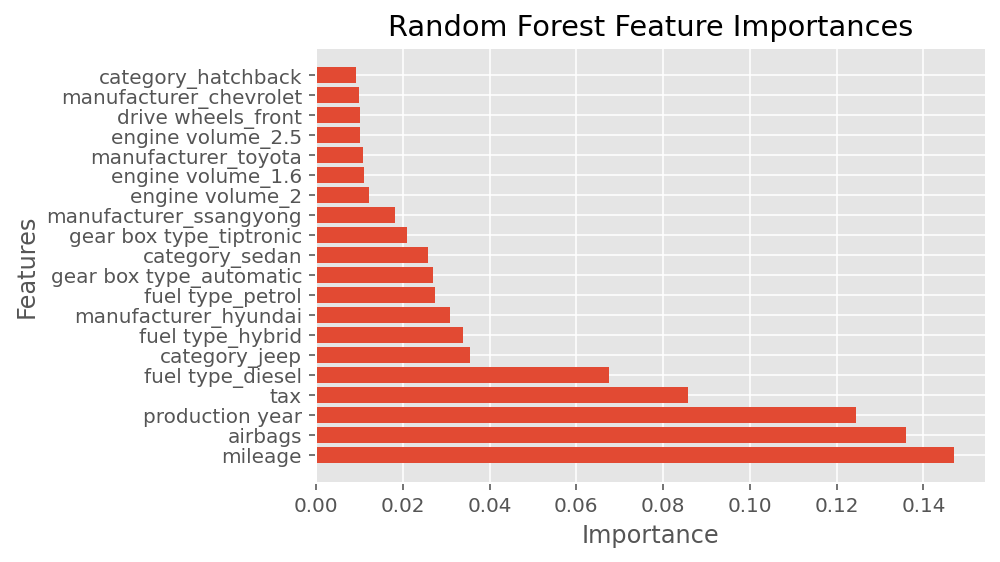

```python
plot_imp(rfi_best_features, rfi_feature_importance, 'Random Forest')
```

## **Data Sampling & Train-Test Splitting**

[output not shown]

```python
n_samples = 9000

data_sample=pd.DataFrame(cars_data).sample(n=n_samples, random_state=9).values
target_sample = pd.DataFrame(target).sample(n=n_samples, random_state=9).values

print(data_sample.shape)
print(target_sample.shape)
```

```
(9000, 115)
(9000, 1)
```

```python
from sklearn.model_selection import train_test_split
X_train, X_test, y_train, y_test = train_test_split(data_sample, target_sample, test_size=0.3, random_state=8)
```

```python
# Printing the shape of the train and test set
print("Train set shape:", X_train.shape, y_train.shape)
print("Test set shape:", X_test.shape, y_test.shape)
```

```
Train set shape: (6300, 115) (6300, 1)
Test set shape: (2700, 115) (2700, 1)
```

## **Model Fitting and HyperParameter Tuning**

```python
from sklearn.model_selection import RepeatedKFold, GridSearchCV
cv_method = RepeatedKFold(n_splits=5, n_repeats=3, random_state=999)
```

## **K-Nearest Neighbors (KNN)**

Using pipeline, we stack feature selection and grid search for KNN hyperparameter tuning via cross-validation. We will use same pipline methodology for Decision Tree, RandomForestRegressor and Linear Regressor model.

The KNN hyperparameters are as follows:

1) number of neighbors (n_neighbors) and

2) the distance metrics (p).

For feature selection, we use the powerful Random Forest Importance (RFI) method with 100 estimator. A trick here is that we need a bit iof coding so that we can make RFI feature selection as part of the pipline. For this reason, we define the custom RFIFeatureSelector() class below to pass in RFI as a "step" to the pipeline.

```python
from sklearn.base import BaseEstimator, TransformerMixin
class RFIFeatureSelector(BaseEstimator, TransformerMixin):

    def __init__(self, n_features_=10):
        self.n_features_ = n_features_
        self.fs_indices_ = None

    def fit(self, cars_data, target):
        from sklearn.ensemble import RandomForestRegressor
        from numpy import argsort
        model_rfi = RandomForestRegressor(n_estimators=100)
        model_rfi.fit(cars_data, target.ravel())
        self.fs_indices_= np.argsort(model_rfi.feature_importances_)[::-1][0:self.n_features_]
        return self

    def transform(self, cars_data, target=None):
        return cars_data[:, self.fs_indices_]
```

```python
from sklearn.pipeline import Pipeline
from sklearn.neighbors import KNeighborsRegressor


cv_method = RepeatedKFold(n_splits=5,  n_repeats=3, random_state=999)
pipe_KNN = Pipeline(steps=[('rfi_fs', RFIFeatureSelector()),
                           ('knn', KNeighborsRegressor())])

params_pipe_KNN = {'rfi_fs__n_features_': [10, 20, cars_data.shape[1]],
                   'knn__n_neighbors': [1, 5, 10],
                   'knn__p': [1, 2, 3]}


gs_pipe_KNN = GridSearchCV(estimator=pipe_KNN,
                           param_grid=params_pipe_KNN,
                           cv=cv_method,
                           refit=True,
                           n_jobs=-2,
                           scoring='r2',
                           verbose=1)
```

```python
fitted_model_KNN= gs_pipe_KNN.fit(X_train, y_train);
```

```
Fitting 15 folds for each of 27 candidates, totalling 405 fits
```

```python
gs_pipe_KNN.best_params_
```

```
{'knn__n_neighbors': 5, 'knn__p': 2, 'rfi_fs__n_features_': 115}
```

```python
gs_pipe_KNN.best_score_
```

```
0.7063066327008746
```

```python
from sklearn import metrics
y_pred_KNN = fitted_model_KNN.predict(X_test)
r2_score= metrics.r2_score(y_test, y_pred_KNN)

r2_score
```

```
0.7594421293335555
```

```python
gs_pipe_KNN.cv_results_['mean_test_score']
```

```
array([0.59065413, 0.64552499, 0.6657511 , 0.58543875, 0.62956018,
       0.66053292, 0.585153  , 0.62673919, 0.65855243, 0.68958972,
       0.70573061, 0.70627805, 0.68733791, 0.70387489, 0.70630663,
       0.68610498, 0.7010602 , 0.70559375, 0.69150325, 0.68724083,
       0.69318218, 0.68668617, 0.68201905, 0.69502133, 0.68648991,
       0.67993588, 0.69448349])
```

```python
import pandas as pd

results_KNN = pd.DataFrame(gs_pipe_KNN.cv_results_['params'])
```

```python
results_KNN['test_score'] = gs_pipe_KNN.cv_results_['mean_test_score']
```

```python
results_KNN['metric'] = results_KNN['knn__p'].replace([1,2,3], ["Manhattan", "Euclidean", "Minkowski"])
results_KNN
```

|  | knn__n_neighbors | knn__p | rfi_fs__n_features_ | test_score | metric |
| --- | --- | --- | --- | --- | --- |
| 0 | 1 | 1 | 10 | 0.590654 | Manhattan |
| 1 | 1 | 1 | 20 | 0.645525 | Manhattan |
| 2 | 1 | 1 | 115 | 0.665751 | Manhattan |
| 3 | 1 | 2 | 10 | 0.585439 | Euclidean |
| 4 | 1 | 2 | 20 | 0.629560 | Euclidean |
| 5 | 1 | 2 | 115 | 0.660533 | Euclidean |
| 6 | 1 | 3 | 10 | 0.585153 | Minkowski |
| 7 | 1 | 3 | 20 | 0.626739 | Minkowski |
| 8 | 1 | 3 | 115 | 0.658552 | Minkowski |
| 9 | 5 | 1 | 10 | 0.689590 | Manhattan |
| 10 | 5 | 1 | 20 | 0.705731 | Manhattan |
| 11 | 5 | 1 | 115 | 0.706278 | Manhattan |
| 12 | 5 | 2 | 10 | 0.687338 | Euclidean |
| 13 | 5 | 2 | 20 | 0.703875 | Euclidean |
| 14 | 5 | 2 | 115 | 0.706307 | Euclidean |
| 15 | 5 | 3 | 10 | 0.686105 | Minkowski |
| 16 | 5 | 3 | 20 | 0.701060 | Minkowski |
| 17 | 5 | 3 | 115 | 0.705594 | Minkowski |
| 18 | 10 | 1 | 10 | 0.691503 | Manhattan |
| 19 | 10 | 1 | 20 | 0.687241 | Manhattan |
| 20 | 10 | 1 | 115 | 0.693182 | Manhattan |
| 21 | 10 | 2 | 10 | 0.686686 | Euclidean |
| 22 | 10 | 2 | 20 | 0.682019 | Euclidean |
| 23 | 10 | 2 | 115 | 0.695021 | Euclidean |
| 24 | 10 | 3 | 10 | 0.686490 | Minkowski |
| 25 | 10 | 3 | 20 | 0.679936 | Minkowski |
| 26 | 10 | 3 | 115 | 0.694483 | Minkowski |

We observe that the difference between the hyperparameter combinations is not really much when condition on the number of features seelcted. Lets visualize the result of the grid search corresponding to 10 selected features.

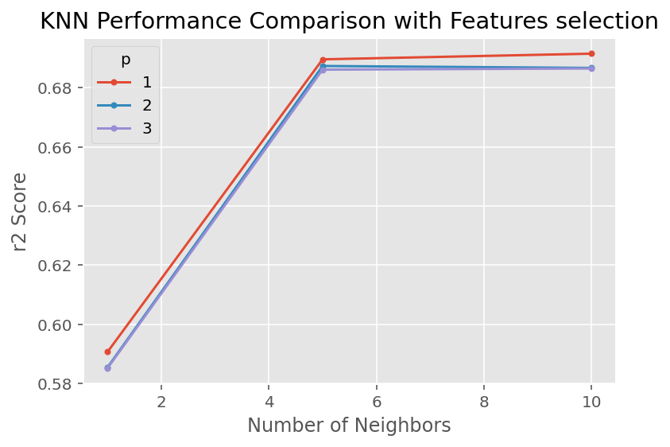

```python
results_KNN_features = results_KNN[results_KNN['rfi_fs__n_features_'] == 10.0]

for i in results_KNN_features['knn__p'].unique():
    temp = results_KNN_features[results_KNN_features['knn__p'] == i]
    plt.plot(temp['knn__n_neighbors'], temp['test_score'], marker = '.', label = i)

plt.legend(title = "p")
plt.xlabel('Number of Neighbors')
plt.ylabel("r2 Score")
plt.title("KNN Performance Comparison with Features selection")
plt.show()
```

## **Decision Trees (DT)**

```python
from sklearn.tree import DecisionTreeRegressor
from sklearn import tree
pipe_DT = Pipeline([('rfi_fs', RFIFeatureSelector()),
                    ('dt', tree.DecisionTreeRegressor())])

params_pipe_DT = {'rfi_fs__n_features_': [10, 20, 30, 40],
                  'dt__max_depth': [ 4, 5, 6, 7, 10],
                  'dt__min_samples_split': [4, 5, 6, 7, 10]}

gs_pipe_DT = GridSearchCV(estimator=pipe_DT,
                          param_grid=params_pipe_DT,
                          cv=cv_method,
                          refit=True,
                          n_jobs=-2,
                          scoring='r2',
                          verbose=1)
```

```python
fitted_model_DT = gs_pipe_DT.fit(X_train, y_train);
```

```
Fitting 15 folds for each of 100 candidates, totalling 1500 fits
```

```python
gs_pipe_DT.best_params_
```

```
{'dt__max_depth': 10, 'dt__min_samples_split': 6, 'rfi_fs__n_features_': 40}
```

```python
gs_pipe_DT.best_score_
```

```
0.7090003496847127
```

```python
y_pred_DT = fitted_model_DT.predict(X_test)
r2_score = metrics.r2_score(y_test, y_pred_DT)

r2_score
```

```
0.7178976204301502
```

```python
results_DT = pd.DataFrame(gs_pipe_DT.cv_results_['params'])
results_DT['test_score'] = gs_pipe_DT.cv_results_['mean_test_score']

results_DT
```

|  | dt__max_depth | dt__min_samples_split | rfi_fs__n_features_ | test_score |
| --- | --- | --- | --- | --- |
| 0 | 4 | 4 | 10 | 0.586454 |
| 1 | 4 | 4 | 20 | 0.588515 |
| 2 | 4 | 4 | 30 | 0.590690 |
| 3 | 4 | 4 | 40 | 0.590958 |
| 4 | 4 | 5 | 10 | 0.586454 |
| ... | ... | ... | ... | ... |
| 95 | 10 | 7 | 40 | 0.707401 |
| 96 | 10 | 10 | 10 | 0.679252 |
| 97 | 10 | 10 | 20 | 0.708443 |
| 98 | 10 | 10 | 30 | 0.707418 |
| 99 | 10 | 10 | 40 | 0.708124 |

100 rows × 4 columns

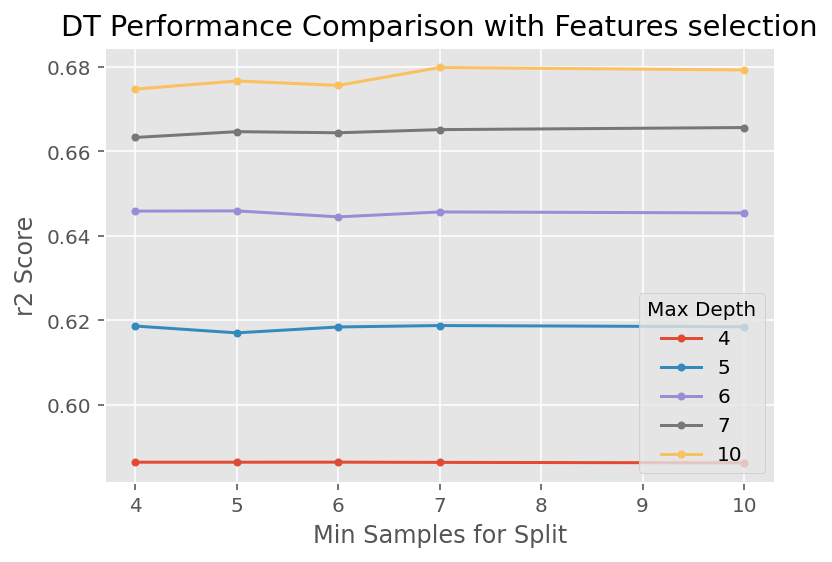

```python
results_DT_features = results_DT[results_DT['rfi_fs__n_features_'] == 10.0]


for i in results_DT_features['dt__max_depth'].unique():
    temp = results_DT_features[results_DT_features['dt__max_depth'] == i]
    plt.plot(temp['dt__min_samples_split'], temp['test_score'], marker = '.', label = i)

plt.legend(title = "Max Depth")
plt.xlabel('Min Samples for Split')
plt.ylabel("r2 Score")
plt.title("DT Performance Comparison with Features selection")
plt.show()
```

## **Random Forest**

We build a RFR using combinations of feature selection (rfi_fs**n*features*) , Number of trees (rf**n_estimators), Maximum Depth of each tree (rf**max_depth), minimum sample to split in internal nodes (rf**min_samples_split), Minimum sample number of sample to be at leaf node (rf__min_samples_leaf).

```python
from sklearn.ensemble import RandomForestRegressor

pipe_RandomForest = Pipeline([('rfi_fs', RFIFeatureSelector()),
                    ('rf', RandomForestRegressor())])

params_pipe_RandomForest = {'rfi_fs__n_features_': [10, 20],
                'rf__n_estimators': [100, 400],
                'rf__max_depth': [5, 10, 20, 30],
                'rf__min_samples_split': [2, 3, 4, 20],
                'rf__min_samples_leaf': [1, 2, 4, 10]
                }

gs_pipe_RandomForest = GridSearchCV(estimator=pipe_RandomForest,
                          param_grid=params_pipe_RandomForest,
                          refit=True,
                          n_jobs=-2,
                          scoring='r2',
                          verbose=1)
```

```python
fitted_model_rf = gs_pipe_RandomForest.fit(X_train, y_train.ravel());
```

```
Fitting 5 folds for each of 256 candidates, totalling 1280 fits
```

```python
gs_pipe_RandomForest.best_params_
```

```
{'rf__max_depth': 20,
 'rf__min_samples_leaf': 1,
 'rf__min_samples_split': 3,
 'rf__n_estimators': 400,
 'rfi_fs__n_features_': 20}
```

```python
gs_pipe_RandomForest.best_score_
```

```
0.7821945128818222
```

```python
y_pred_R_F = fitted_model_rf.predict(X_test)
r2_score= metrics.r2_score(y_test, y_pred_R_F)

r2_score
```

```
0.7847249317801173
```

```python
results_RandomForest = pd.DataFrame(gs_pipe_RandomForest.cv_results_['params'])
results_RandomForest['test_score'] = gs_pipe_RandomForest.cv_results_['mean_test_score']

results_RandomForest
```

|  | rf__max_depth | rf__min_samples_leaf | rf__min_samples_split | rf__n_estimators | rfi_fs__n_features_ | test_score |
| --- | --- | --- | --- | --- | --- | --- |
| 0 | 5 | 1 | 2 | 100 | 10 | 0.643979 |
| 1 | 5 | 1 | 2 | 100 | 20 | 0.649597 |
| 2 | 5 | 1 | 2 | 400 | 10 | 0.644518 |
| 3 | 5 | 1 | 2 | 400 | 20 | 0.649864 |
| 4 | 5 | 1 | 3 | 100 | 10 | 0.645277 |
| ... | ... | ... | ... | ... | ... | ... |
| 251 | 30 | 10 | 4 | 400 | 20 | 0.737397 |
| 252 | 30 | 10 | 20 | 100 | 10 | 0.719836 |
| 253 | 30 | 10 | 20 | 100 | 20 | 0.735960 |
| 254 | 30 | 10 | 20 | 400 | 10 | 0.720481 |
| 255 | 30 | 10 | 20 | 400 | 20 | 0.738293 |

256 rows × 6 columns

[figure not shown]

```python
results_features = results_RandomForest[results_RandomForest['rfi_fs__n_features_'] == 10.0]

for i in results_features['rf__min_samples_leaf'].unique():
    temp = results_features[results_features['rf__min_samples_leaf'] == i]
    plt.plot(temp['rf__max_depth'], temp['test_score'], marker = '.', label = i)


plt.xlabel('Number of Neighbors')
plt.ylabel("r2 Score")
plt.title(" RandomForest Performance Comparison with 10 Features")
plt.show()
```

### **Ridge Regressor Models**

We build a Regressor models using combinations of alpha parameter in Ridge regression(r**alpha), intercept term in the model(r**fit_intercept), normalize the input variable(r**normalize), algorithm for ridge regression problem(r**solver), random seed (r__random_state)

```python
# Regression Models
from sklearn.linear_model import LinearRegression, Ridge, Lasso
from sklearn.metrics import r2_score
```

```python
# Liner Regression
linear_model = LinearRegression()
linear_model.fit(X_train, y_train)
linear_predictions = linear_model.predict(X_test)

# Ridge Regression
ridge_model = Ridge()
ridge_model.fit(X_train,y_train)
ridge_predictions = ridge_model.predict(X_test)

#Lasso Regression
lasso_model = Lasso()
lasso_model.fit(X_train, y_train)
lasso_predictions = lasso_model.predict(X_test)
```

```python
ridge_accuracy = r2_score(y_test, ridge_predictions)
lasso_accuracy = r2_score(y_test, lasso_predictions)
ridge_accuracy
lasso_accuracy
```

```
0.5294559086095507
```

```python
print("Ridge Regression Accuracy:", ridge_accuracy)
print("Lasso Regression Accuracy:", lasso_accuracy)
```

```
Ridge Regression Accuracy: 0.5295598534675788
Lasso Regression Accuracy: 0.5294559086095507
```

```python
from sklearn.linear_model import LinearRegression, Ridge, Lasso

pipe_Ridge = Pipeline([('rfi_fs', RFIFeatureSelector()),
                    ('r', Ridge())])

params_pipe_ridge = {
    'r__alpha': [0.1, 1.0, 10.0],
    'r__fit_intercept': [True, False],
    'r__normalize': [True, False],
    'r__copy_X': [True, False],
    'r__solver': ['auto', 'svd', 'cholesky', 'lsqr', 'sparse_cg', 'sag', 'saga'],
    'r__random_state': [None, 42]
}


gs_pipe_ridge = GridSearchCV(estimator=pipe_Ridge,
                          param_grid=params_pipe_ridge,
                          refit=True,
                          n_jobs=-2,
                          scoring='r2',
                          verbose=1)
```

```python
fitted_model_r = gs_pipe_ridge.fit(X_train, y_train);
```

```
Fitting 5 folds for each of 336 candidates, totalling 1680 fits
```

```python
gs_pipe_ridge.best_params_
```

```
{'r__alpha': 0.1,
 'r__copy_X': True,
 'r__fit_intercept': True,
 'r__normalize': False,
 'r__random_state': 42,
 'r__solver': 'saga'}
```

```python
y_pred_r = fitted_model_r.predict(X_test)
r2_score= metrics.r2_score(y_test, y_pred_r)

r2_score
```

```
0.5295598534675788
```

```python
gs_pipe_ridge.best_score_
```

```
0.5294559086095507
```

```python
results_ridge = pd.DataFrame(gs_pipe_ridge.cv_results_['params'])
results_ridge['test_score'] = gs_pipe_ridge.cv_results_['mean_test_score']

results_ridge
```

|  | r__alpha | r__copy_X | r__fit_intercept | r__normalize | r__random_state | r__solver | test_score |
| --- | --- | --- | --- | --- | --- | --- | --- |
| 0 | 0.1 | True | True | True | NaN | auto | 0.370521 |
| 1 | 0.1 | True | True | True | NaN | svd | 0.371568 |
| 2 | 0.1 | True | True | True | NaN | cholesky | 0.370521 |
| 3 | 0.1 | True | True | True | NaN | lsqr | 0.371563 |
| 4 | 0.1 | True | True | True | NaN | sparse_cg | 0.370404 |
| ... | ... | ... | ... | ... | ... | ... | ... |
| 331 | 10.0 | False | False | False | 42.0 | cholesky | 0.352658 |
| 332 | 10.0 | False | False | False | 42.0 | lsqr | 0.353520 |
| 333 | 10.0 | False | False | False | 42.0 | sparse_cg | 0.354914 |
| 334 | 10.0 | False | False | False | 42.0 | sag | 0.352513 |
| 335 | 10.0 | False | False | False | 42.0 | saga | 0.353986 |

336 rows × 7 columns

## Neural Network Topology:

The created NN demonstrate for Cars Cost Prediction comprises of numerous layers, counting input, covered up, and output layers. The topology is as takes after:

- Input layer:

The responsibility of the input layer is to receive the feature inputs of automobiles, including details like brand, make, mileage, engine displacement, etc. The quantity of neurons in the input layer is established based on the count of input features within the given dataset.

- Hidden Layers:

The concealed layers are accountable for acquiring intricate patterns and interconnections within the data. The hyperparameters that require adjustment include the quantity of obscured layers and the quantity of neurons contained within each layer.

- Output Layer:

Using the learned patterns from the hidden layers, the output layer generates an estimation for car prices. The outcome of the Cars Price Prediction assignment involves a solitary neuron located in the output layer that represents the anticipated cost.

## The relevant model parameter values

We optimized the NN model's performance by fine-tuning several hyperparameters. The hyperparameters were adjusted for optimal performance.

- Number of Hidden Layers:

- Batch Size:

The quantity of data samples employed in every iteration of the training procedure is determined by the batch size. We experimented with varying batch sizes, ranging from 32 to 128, to strike a balance between optimizing computational efficiency and achieving model convergence.

- Learning Rate:

The learning rate determines the step size during the weight and bias update in the optimization process. We experimented with different learning rates, such as 0.001, 0.01, or 0.1, to find the value that leads to faster convergence and better performance.

- Number of Neurons in Hidden Layers:

We experimented with different neuron quantities in the hidden layers to determine the ideal trade-off between model intricacy and effectiveness. Various neuron count configurations, including 16, 32, 64, or 128 neurons in every concealed layer, were experimented with.

- Regularization Techniques:

Various regularization methods including L1 and L2 regularization, dropout, and early stopping were implemented to avoid overfitting and enhance generalization performance.